# Building data

- Jordan Maulino jpmaulino@dons.usfca.edu
- Chezka Sino msino@dons.usfca.edu
- Bob Horton cybertory@gmail.com or rhorton@microsoft.com

## Simulated Patient Readmission Data

This simulation builds on a semi-simulated dataset of hospital readmission data from diabetes patients.

The dataset given is a largescale semi-simulated dataset that was created from published data regarding hospital readmission rates for diabetic patients. The analytical features which appear in the data were engineered from a variety of additional simulated data sources. These included grocery purchases (to estimate the percentage calories from carbohydrates in a patient’s diet) and wearable vital sign sensor data (to quantify activity).

We were asked to extend this project by adding a genetic confounder to the dataset in order to simulate Simpson’s Paradox.

### Binomial logistic regression

```r
setwd("C:\\Users\\shinheera\\Documents\\CHICHU\\USF Files\\Fall 2016\\CS 640\\Project")
set.seed(1)
patients <- read.csv("simulated_readmission_data.csv")
patients$readmit30 <- patients$readmitted == "<30"
sim_cols <- c("bmi","pct_calories_from_carbs","minutes_walking","sd_glucose")
lapply(patients[sim_cols], max)
```

```
## $bmi
## [1] Inf
##
## $pct_calories_from_carbs
## [1] 82.78495
##
## $minutes_walking
## [1] 411
##
## $sd_glucose
## [1] 7.547726
```

```r
sum(is.infinite(patients$bmi))
```

```
## [1] 500
```

```r
patients$bmi[is.infinite(patients$bmi)] <- NA

pts <- patients[c("readmitted", "readmit30", sim_cols)]
pts <- pts[complete.cases(pts),]

form <- formula("readmit30 ~ bmi + pct_calories_from_carbs + minutes_walking + sd_glucose")
fit1 <- glm(form, pts, family=binomial(link="logit"))
summary(fit1)
```

```
##
## Call:
## glm(formula = form, family = binomial(link = "logit"), data = pts)
##
## Deviance Residuals:
##     Min       1Q   Median       3Q      Max
## -3.8683  -0.0113  -0.0002   0.0000   4.1876
##
## Coefficients:
##                           Estimate Std. Error z value Pr(>|z|)
## (Intercept)             -47.881200   1.084286  -44.16   <2e-16 ***
## bmi                       0.532937   0.014733   36.17   <2e-16 ***
## pct_calories_from_carbs   0.523030   0.013651   38.32   <2e-16 ***
## minutes_walking          -0.053886   0.001572  -34.28   <2e-16 ***
## sd_glucose                1.056010   0.044112   23.94   <2e-16 ***
## ---
## Signif. codes:  0 '***' 0.001 '**' 0.01 '*' 0.05 '.' 0.1 ' ' 1
##
## (Dispersion parameter for binomial family taken to be 1)
##
##     Null deviance: 33475  on 50463  degrees of freedom
## Residual deviance:  3803  on 50459  degrees of freedom
## AIC: 3813
##
## Number of Fisher Scoring iterations: 10
```

```r
coef(fit1)['pct_calories_from_carbs']
```

```
## pct_calories_from_carbs
##               0.5230297
```

## Confounding the effect of the percentage of calories from carbs

The coefficient of percentage of calories from carbs is positive (about 0.52), meaning that probability of readmission goes up with higher percentage calories from carbs. We want to design a confounder so the coefficient of calories comes out negative; that is, within each genetic group, the probability of readmission should go *down* as a patient’s percentage calories from carbs goes up.

We will use the same approach our project sponsor, Bob Horton, used in his blog post on simulating Simpson’s Paradox through confounders (http://blog.revolutionanalytics.com/2015/11/fun-with-simpsons-paradox-simulating-confounders.html).

To do so, we need to use a continuous variable which corresponds to the probability of being readmitted in regard to a patient’s percent calories from carbs.

Below, we create the variable readmission_score in order to assign numerical scores to the categorical variable readmitted.

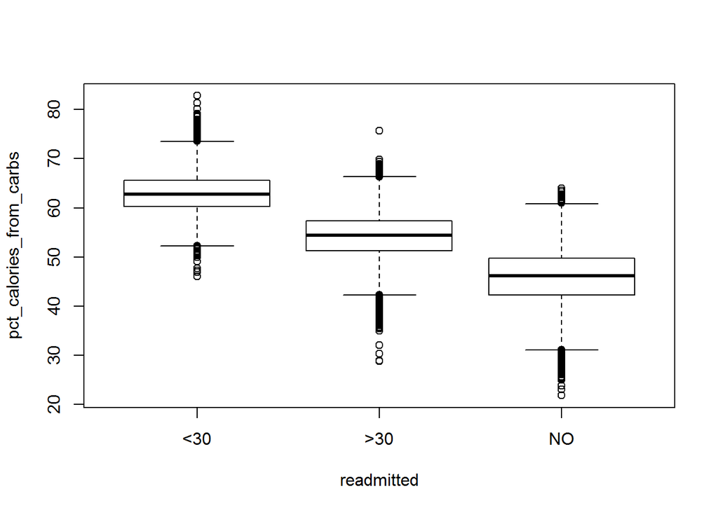

```r
plot( pct_calories_from_carbs ~ readmitted, data=pts)
```

```r
library(dplyr)
(readmitted_pct_cal <- pts %>% group_by(readmitted) %>% summarize(mean_pct_cal=mean(pct_calories_from_carbs)))
```

```
## # A tibble: 3 × 2
##   readmitted mean_pct_cal
##       <fctr>        <dbl>
## 1        <30     63.03642
## 2        >30     54.15258
## 3         NO     45.84841
```

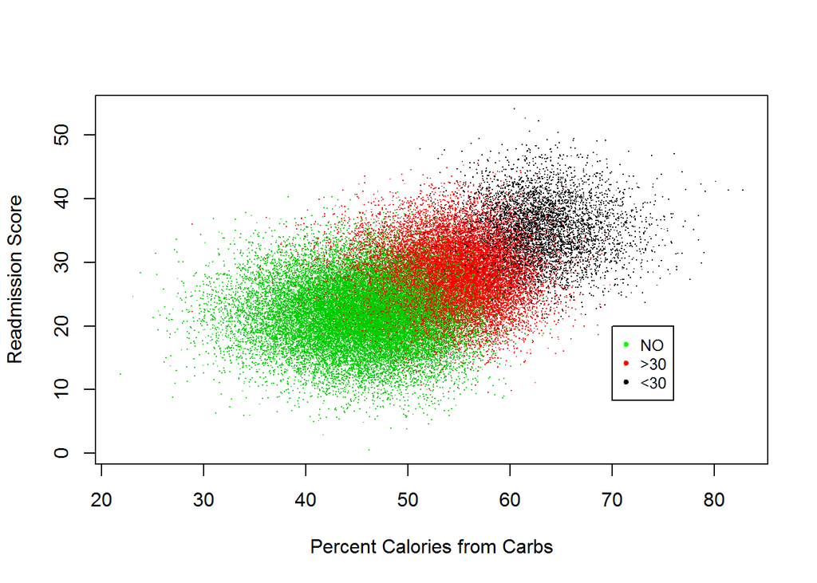

```r
mean_pct_cal <- readmitted_pct_cal$mean_pct_cal
names(mean_pct_cal) <- readmitted_pct_cal$readmitted

readmit_score_mean <- c("<30"=35, ">30"=28, "NO"=22)

pts <- transform(pts, readmission_score=rnorm(nrow(pts), mean=readmit_score_mean[readmitted], sd=5))
with(pts, plot(readmission_score ~ pct_calories_from_carbs, col=readmitted, pch='.', xlab = "Percent Calories from Carbs", ylab = "Readmission Score"))
legend(70, 20, c("NO", ">30", "<30"),cex = .8, pch=20, col=c("green", "red", "black"))
```

The plot above displays a scatterplot of the patients’ readmission scores in regard to their percent calories from carbohydrates.

Next, we will group these points into a set of parallel stripes with slopes which go in the opposite direction of the general trend from the scatterplot above.

## Drawing Stripes

```r
point_line_distance <- function(b, m, x, y)
  (y - (m*x + b))/sqrt(m^2 + 1)

confounded_data_frame <- function(x, y, m, num_grp){
  b <- 0 # intercept doesn't matter
  d <- point_line_distance(b, m, x, y)
  d_scaled <- 0.0005 + 0.999 * (d - min(d))/(max(d) - min(d)) # avoid 0 and 1
  data.frame(x=x, y=y,
             group=as.factor(sprintf("grp%02d", ceiling(num_grp*(d_scaled)))))
}
numGroups <- 25
rbow <- rainbow(numGroups, end=2/3)
confounded <- confounded_data_frame(pts$pct_calories_from_carbs, pts$readmission_score, -4.10, numGroups)
```

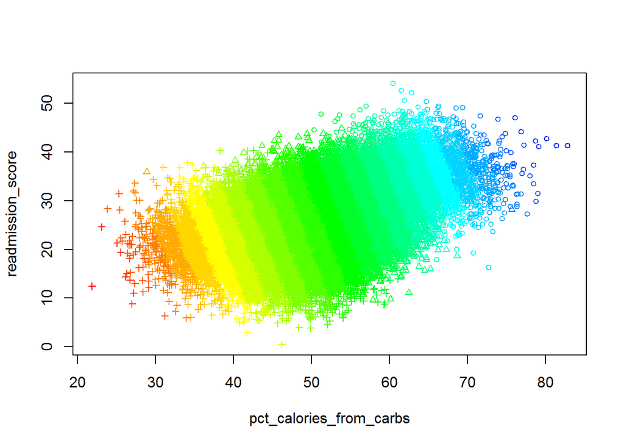

```r
pts$group <- confounded$group

with(pts, plot(readmission_score ~ pct_calories_from_carbs,
               col=rbow[as.integer(group)],
               pch=as.integer(readmitted),
               cex=0.75))
```

```r
fit <- glm(readmit30 ~ group:pct_calories_from_carbs, pts, family=binomial(link="logit"))

coef(fit)
```

```
##                        (Intercept) groupgrp01:pct_calories_from_carbs
##                        18.46483188                        -1.78558858
## groupgrp02:pct_calories_from_carbs groupgrp03:pct_calories_from_carbs
##                        -1.58897403                        -1.49739043
## groupgrp04:pct_calories_from_carbs groupgrp05:pct_calories_from_carbs
##                        -1.34661783                        -1.24028715
## groupgrp06:pct_calories_from_carbs groupgrp07:pct_calories_from_carbs
##                        -1.14323444                        -1.06380324
## groupgrp08:pct_calories_from_carbs groupgrp09:pct_calories_from_carbs
##                        -0.99016838                        -0.92828542
## groupgrp10:pct_calories_from_carbs groupgrp11:pct_calories_from_carbs
##                        -0.87430845                        -0.57558692
## groupgrp12:pct_calories_from_carbs groupgrp13:pct_calories_from_carbs
##                        -0.52016871                        -0.46920674
## groupgrp14:pct_calories_from_carbs groupgrp15:pct_calories_from_carbs
##                        -0.41278532                        -0.36840405
## groupgrp16:pct_calories_from_carbs groupgrp17:pct_calories_from_carbs
##                        -0.32682011                        -0.28783713
## groupgrp18:pct_calories_from_carbs groupgrp19:pct_calories_from_carbs
##                        -0.25300607                        -0.22812167
## groupgrp20:pct_calories_from_carbs groupgrp21:pct_calories_from_carbs
##                        -0.19014481                         0.02924292
## groupgrp22:pct_calories_from_carbs groupgrp23:pct_calories_from_carbs
##                        -0.19494996                         0.02728919
## groupgrp24:pct_calories_from_carbs groupgrp25:pct_calories_from_carbs
##                         0.02689514                         0.02572813
```

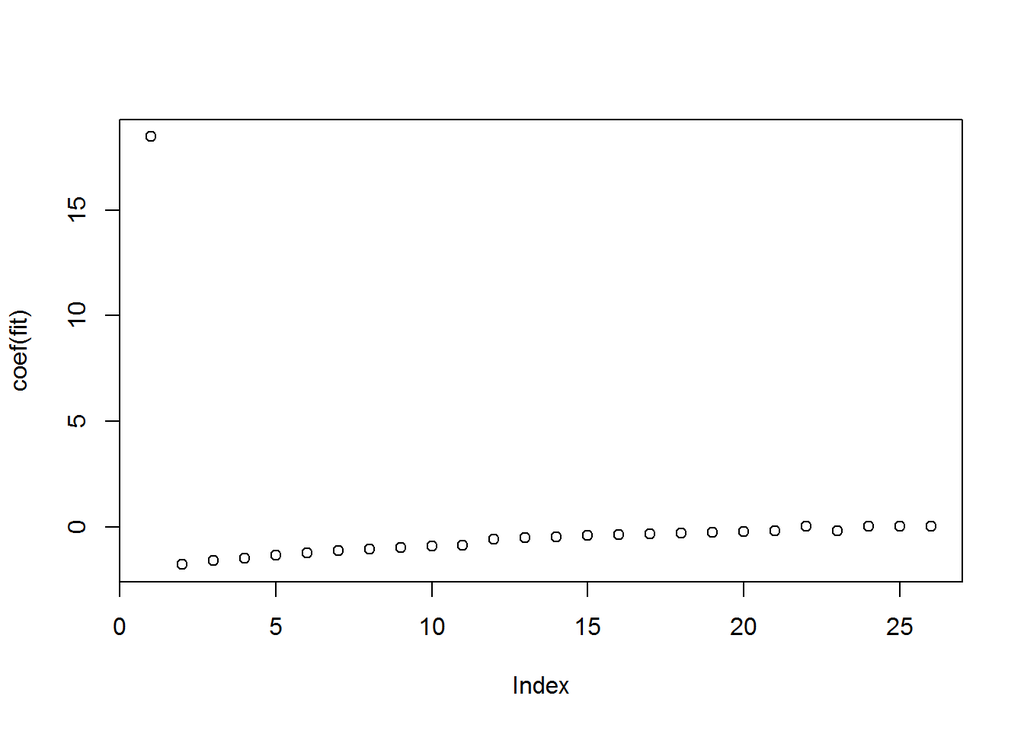

```r
plot(coef(fit))
```

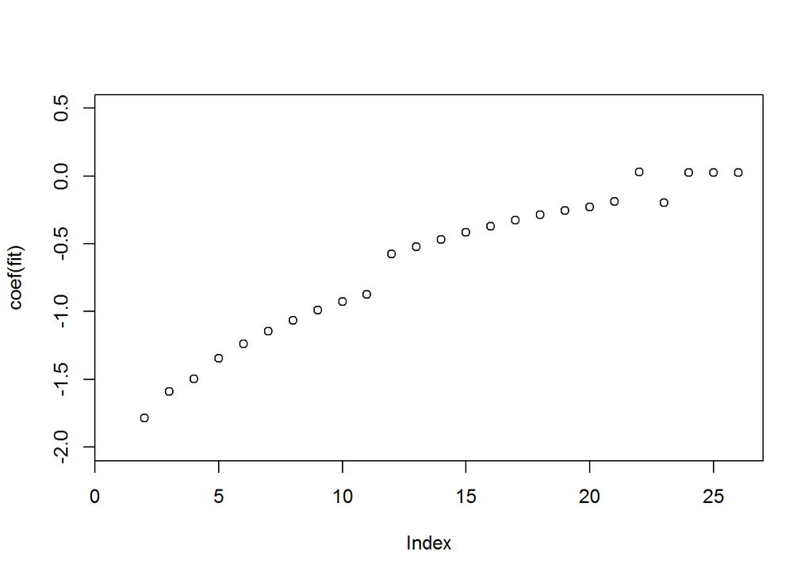

```r
plot(coef(fit), ylim=c(-2, 0.5))
```

From striped plot above, we can choose one of the groups to use as our genetic confounder. Let’s take a look at the density plots of each stripe to see which one could produce some interesting results…

## Checking the densities of each group

[figure not shown]

```r
library(ggplot2)

ggplot(pts, aes(x=pct_calories_from_carbs, fill=readmitted)) + geom_density(alpha=0.5) + facet_grid(group ~ .)
```

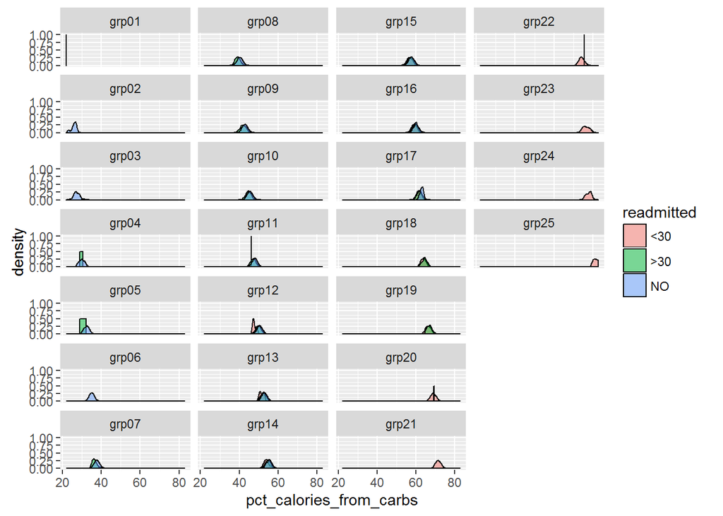

```r
# fig.height = 12

ggplot(pts, aes(x=pct_calories_from_carbs, fill=readmitted)) + geom_density(alpha=0.5) + facet_wrap(~group, ncol=4, dir='v')
```

```r
# fig.height = 12

xtabs( ~ readmitted + group, pts)
```

```
##           group
## readmitted grp01 grp02 grp03 grp04 grp05 grp06 grp07 grp08 grp09 grp10
##        <30     0     0     0     0     0     0     0     0     0     0
##        >30     0     0     0     2     2     0    13    39   156   437
##        NO      1     8    32   114   345   790  1592  2782  4058  5012
##           group
## readmitted grp11 grp12 grp13 grp14 grp15 grp16 grp17 grp18 grp19 grp20
##        <30     1     4    15    90   307   788  1290  1240   788   415
##        >30  1041  2217  3584  4128  3538  1922   623   127    29     2
##        NO   5106  4066  2297   934   220    41     6     0     0     0
##           group
## readmitted grp21 grp22 grp23 grp24 grp25
##        <30   185    53    15     5     3
##        >30     0     1     0     0     0
##        NO      0     0     0     0     0
```

After taking a look at the density plots and frequency tables for each group, we dedcided that **group 16** would be an excellent group to use as our genetic confounder because it has a good amount ofoverlap in patients who were readmitted within 30 days and those who were readmitted after 30 days. By confounding this group, it would be plausible to argue that there is another factor playing a role in a patient’s likelihood to be readmitted within the first 30 days of being discharged in regard to the amount of calories from carbohydrates they consume.

We chose the gene IRS1 to use as our genetic confounder. Mutations in this gene have been reported to have a role in determining susceptibility traits related to type 2 diabetes. We choose its RR allele to act as our confounder, is it is the rarest genotype for this gene. Because the confounded stripe is only roughly 1/25th of the data, it makes sense to assign this allele to it. For the sake of simplicity, we assign the other two alleles such that all of the patients in the groups preceding group 16 have the GG allele and those following group 16 have the GR allele.

## Assigning the alleles to the groups

```r
irs1 <- rep("GR", nrow(pts))
pts[["irs1"]] <- irs1
pts$irs1 <- ifelse(pts$group == "grp16", "RR", pts$irs1)

for (i in 1:9) {
  groupName <- paste("grp0", i, sep="")
  pts$irs1 <- ifelse(pts$group == groupName, "GG", pts$irs1)
}

for (i in 0:5) {
  groupName <- paste("grp1", i, sep="")
  pts$irs1 <- ifelse(pts$group == groupName, "GG", pts$irs1)
}

pts$irs1 <- as.factor(pts$irs1)
```

# Drawing the stripes again, now with the confounded variable

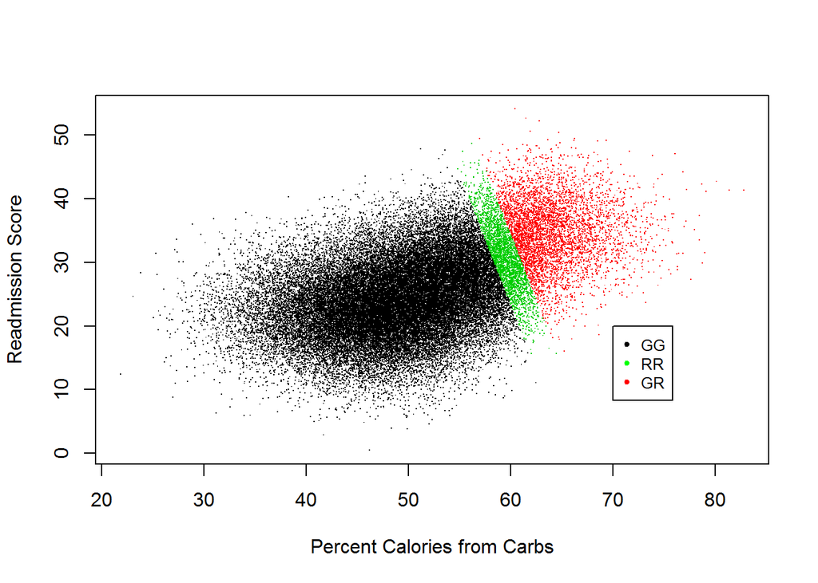

```r
par(mfrow = c(1,1))
with(pts, plot(readmission_score ~ pct_calories_from_carbs, col = irs1, pch='.', xlab = "Percent Calories from Carbs", ylab = "Readmission Score"))
legend(70, 20, c("GG", "RR", "GR"),cex = .8, pch=20, col=c("black", "green", "red"))
```

```r
fit <- lm(readmission_score ~ irs1* pct_calories_from_carbs, pts)
summary(fit)
```

```
##
## Call:
## lm(formula = readmission_score ~ irs1 * pct_calories_from_carbs,
##     data = pts)
##
## Residuals:
##      Min       1Q   Median       3Q      Max
## -23.0274  -3.5915  -0.0392   3.5691  23.0915
##
## Coefficients:
##                                  Estimate Std. Error t value Pr(>|t|)
## (Intercept)                     12.594518   0.209677   60.07   <2e-16 ***
## irs1GR                          31.464729   1.511581   20.82   <2e-16 ***
## irs1RR                         196.991452   4.509207   43.69   <2e-16 ***
## pct_calories_from_carbs          0.236306   0.004293   55.05   <2e-16 ***
## irs1GR:pct_calories_from_carbs  -0.379534   0.023662  -16.04   <2e-16 ***
## irs1RR:pct_calories_from_carbs  -3.243272   0.075914  -42.72   <2e-16 ***
## ---
## Signif. codes:  0 '***' 0.001 '**' 0.01 '*' 0.05 '.' 0.1 ' ' 1
##
## Residual standard error: 5.402 on 50458 degrees of freedom
## Multiple R-squared:  0.3302, Adjusted R-squared:  0.3301
## F-statistic:  4974 on 5 and 50458 DF,  p-value: < 2.2e-16
```

```r
coef(fit)
```

```
##                    (Intercept)                         irs1GR
##                     12.5945184                     31.4647286
##                         irs1RR        pct_calories_from_carbs
##                    196.9914518                      0.2363060
## irs1GR:pct_calories_from_carbs irs1RR:pct_calories_from_carbs
##                     -0.3795342                     -3.2432717
```

```r
slope <- coef(fit)[6]
slope
```

```
## irs1RR:pct_calories_from_carbs
##                      -3.243272
```

The green stripe in the scatterplot above clearly shows a confounding relationship between the IRS1 RR allele and a patient’s probability of readmission in regard to the amount of calories from carbohydrates they consume.

## Saving the data

```r
pts_noGrp <- subset(pts, select = -c(group))

pts_noGrp$readmission_score <- NULL

write.csv(pts_noGrp, file = "sim_data.csv")
```